[figure not shown]

[figure not shown]

**Métodos Estatísticos em Pesquisa Científica**

**Análise do Questionário 2020**

# Dados

```r
# Pacotes necessários

library(splitstackshape, quietly = TRUE)
library(scales)
library(psych)
library(lubridate)
library(pander)
library(DT)
library(plyr)
library(ggplot2)

# Leitura dos dados

#path <- "./resp_teste.csv"
path <- "C:/Users/briel/Desktop/2020/ce009elt/monitores/Questionário perfil alunos (respostas) - Respostas ao formulário 1.csv"

tabela <- read.csv(path, sep = ',', encoding = 'UTF-8')
#quest <- read.csv(path, sep = ',', encoding = 'latin1')


# Excluindo a primeira coluna referente aos carimbos de data e hora do google forms
tabela <- tabela[,-1]

# Classificacao das variaves
# lo/ln - var qualitativa ordinal, nominal
# td - var quantitativa discreta

# Renomeando as colunas
names(tabela) <- c("ano","satisf","programas","cursou_est","soft_usa","import_est","sexo","irmao","origem","moradia","transporte","habilitacao","temp_ate_univ","altura","peso","pet","instrumento","nascimento","facebook","taxi_pmes","netflix","anos_foto","expect_curso","notacurso")

paleta <- c('#F78181', #vermelho
            '#21610B', #verde escuro
            '#A9F5F2', #azul
            '#81F781', #verde
            '#2E9AFE', #azul2
            '#F781F3', #rosa
            '#610B21', #vermelho escuro
            '#F3F781', #amarelo
            '#08088A', #azul escuro
            '#086A87', #azul3
            '#58FA82', #laranja
            '#21610B' #verde escuro
)
```

| ano | satisf | programas | cursou_est | soft_usa | import_est | sexo | irmao | origem | moradia | transporte | habilitacao | temp_ate_univ | altura | peso | pet | instrumento | nascimento | facebook | taxi_pmes | netflix | anos_foto | expect_curso | notacurso |
| --- | --- | --- | --- | --- | --- | --- | --- | --- | --- | --- | --- | --- | --- | --- | --- | --- | --- | --- | --- | --- | --- | --- | --- |
| 2018 | Neutro | Iniciação científica | 0 | Excel | 7 | Masculino | 2 | Curitiba ou região metropolitana | Com outros familiares | Carro/moto próprio | B (carro) | 18 | 180 | 79 | Gato; Cachorro | Não | 08/06/1999 | Outras | 2 | Não | 40 | Continuar estudos de pós graduação | 60 |
| 2018 | Neutro | Iniciação científica | 0 | Excel | 8 | Masculino | 1 | Curitiba ou região metropolitana | Com os pais | Carro/moto próprio | B (carro) | 15 | 175 | 67 | Cachorro | Violão | 20/09/2000 | Facebook, Instagram | 4 | Sim | 30 | Conseguir um emprego. | 70 |
| 2018 | Satisfeito | Iniciação científica, Bolsista de (algum outro) projeto | 0 | Nunca utilizei um software estatístico | 7 | Feminino | 2 | Curitiba ou região metropolitana | Com outros familiares | Transporte público | Não | 60 | 156 | 51 | Não | Não | 10/01/2001 | Facebook, Instagram, Linkedin | 5 | Não | 50 | Continuar estudos de pós graduação | 85 |
| 2017 | Satisfeito | Nenhum | 0 | Excel | 5 | Masculino | 1 | Curitiba ou região metropolitana | Com os pais | Carro/moto próprio | B (carro) | 15 | 171 | 70 | Gatos | Não | 16/03/2020 | Outras | 1 | Não | 43 | Conseguir um emprego. | 85 |

# Análise exploratória

Existem dois tipos de variáveis: as numéricas (**quantitativas**) e as não numéricas (**qualitativas**), cada uma das classes tem suas ramificações:

**Variáveis Quantitativas**: assumem valores numéricos.

Podem ser:

- **Discretas**: características mensuráveis que podem assumir apenas um número finito ou infinito contável de valores e, assim, somente fazem sentido valores inteiros.
- **Contínuas**: características mensuráveis que assumem valores em uma escala contínua, isto é, na reta real.

**Variáveis Qualitativas**: são as características definidas categorias, ou seja, representam uma classificação dos indivíduos e não uma característica numérica.

Podem ser:

- **Nominais**: não existe ordenação nem peso entre as categorias.
- **Ordinais**: existe uma ordenação entre as categorias.

Formas convenientes de sintetizar dados é por meio de tabelas de frequência e gráficos.

Cuidados devem ser tomados no que diz respeito à escolha do tipo de gráfico para representar a variável com o intuito de evitar que o gráfico fique desproporcional ou privilegiando determinados valores a fim de induzir conclusões àqueles que utilizam o gráfico como forma de visualização.

A escolha do gráfico está diretamente ligada ao tipo das variáveis. Além disso, existem gráficos que permitem análises de mais de uma variável simultâneamente a fim de verificar como uma influencia a outra(s).

Algumas possibilidades de gráficos para cada tipo de variável são:

- **Qualitativa nominal ou ordinal**: setores, barras.
- **Quantitativa discreta**: barras, histograma, boxplot.
- **Quantitativas contínuas**: histograma ou boxplot.
- **Análises bivariadas**:
  - *Quantivativa vs Quantitativa*: Diagrama de dispersão.
  - *Qualitativa vs Quantitativa*: Boxplots.
  - *Qualitativa vs Qualitativa*: Gráfico de mosaico.

# Análise univariada

Vamos analisar, uma a uma, as questões do questionário

## Questões acadêmicas

### Em qual ano você iniciou seu atual curso de graduação?

#### Tabela 1

```r
fa_ano <- table(tabela$ano)   # frequência absoluta
fr_ano <- prop.table(fa_ano) # frequência relativa
fac_ano <- cumsum(fr_ano)    # frequência acumulada
da.ano <- data.frame(niveis=names(fa_ano),Freq=as.vector(fa_ano),freqR=as.vector(fr_ano),freqA=as.vector(fac_ano))
da.ano[4,1] <- 0
levels(da.ano$niveis) <- c(2017,2018,2019,2020)
da.ano[4,] <- da.ano[3,]
da.ano[4,1] <- 2020
da.ano[3,c(2,3,4)] <- c(0,0,0)
pander:::pander(da.ano) # gerando a tabela
```

| niveis | Freq | freqR | freqA |
| --- | --- | --- | --- |
| 2017 | 8 | 0.3333 | 0.3333 |
| 2018 | 15 | 0.625 | 0.9583 |
| 2019 | 0 | 0 | 0 |
| 2020 | 1 | 0.04167 | 1 |

#### Gráfico 1

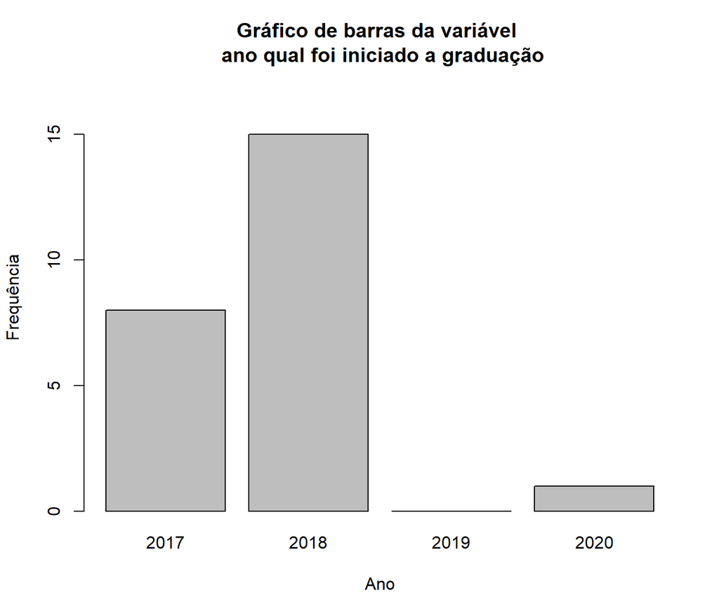

```r
barplot(da.ano$Freq, names.arg = da.ano$niveis, xlab = 'Ano', ylab = "Frequência" ,ylim = c(0,17), main = "Gráfico de barras da variável \n ano qual foi iniciado a graduação")
```

### Qual seu grau de satisfação com o curso atualmente?

#### Tabela 1

```r
fa_satisf <- table(tabela$satisf) # frequência absoluta
fr_satisf <- prop.table(fa_satisf) # frequência relativa
fac_satisf <- cumsum(fr_satisf) # frequência acumulada
da.satisf <- data.frame(niveis = names(fa_satisf), Freq=as.vector(fa_satisf),FreqR=as.vector(fr_satisf),FreqA=as.vector(fac_satisf))
da.satisf$niveis <- as.vector(da.satisf$niveis)
da.satisf[5,] <- NA
da.satisf[5,1] <- "Muito insatisfeito"
da.satisf[5,c(2,3,4)] <- c(0,0,0)
da.satisf2 <- da.satisf
da.satisf[1,] <- da.satisf2[5,]
da.satisf[2,] <- da.satisf2[1,]
da.satisf[5,] <- da.satisf2[2,]
rm(da.satisf2)
pander:::pander(da.satisf)
```

| niveis | Freq | FreqR | FreqA |
| --- | --- | --- | --- |
| Muito insatisfeito | 0 | 0 | 0 |
| Insatisfeito | 2 | 0.08333 | 0.08333 |
| Neutro | 6 | 0.25 | 0.375 |
| Satisfeito | 15 | 0.625 | 1 |
| Muito satisfeito | 1 | 0.04167 | 0.125 |

#### Gráfico

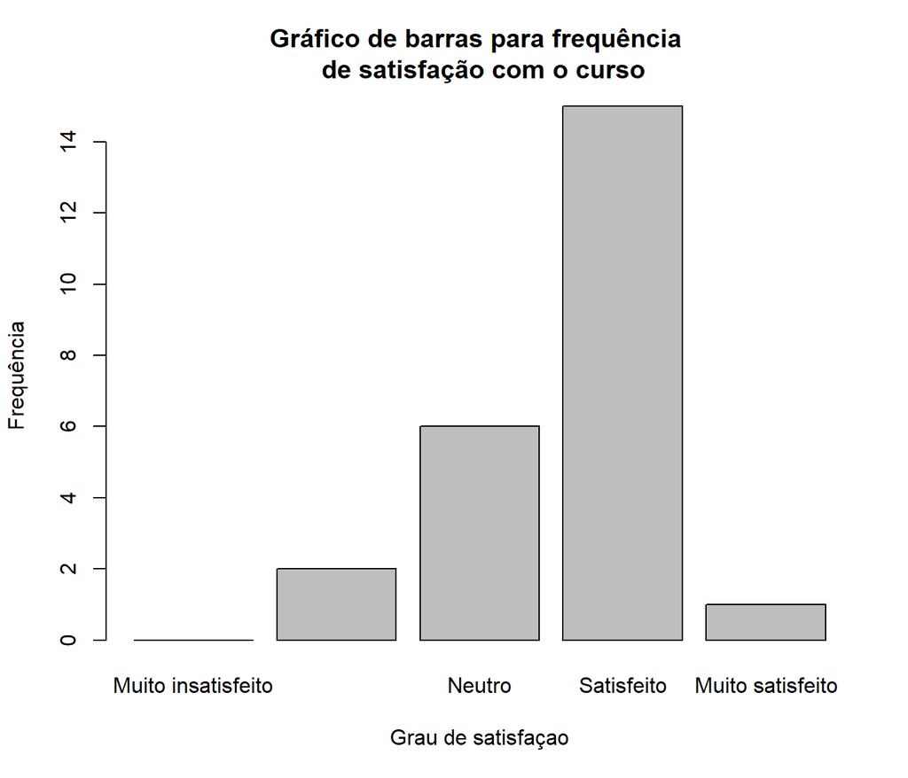

```r
barplot(da.satisf$Freq, names.arg = da.satisf$niveis, main = 'Gráfico de barras para frequência \n de satisfação com o curso', ylab = "Frequência", xlab = "Grau de satisfaçao")
```

### Voce já cursou a disciplina de estatística antes quantas vezes?

#### Tabela

```r
fa_cursou <- table(tabela$cursou_est)
fr_cursou <- prop.table(fa_cursou)
fac_cursou <- cumsum(fr_cursou)
da.cursou <-  data.frame(niveis = names(fa_cursou),
                         Freq = as.vector(fa_cursou),
                         FreqR = as.vector(fr_cursou),
                         FreqA = as.vector(fac_cursou))
pander:::pander(da.cursou)
```

| niveis | Freq | FreqR | FreqA |
| --- | --- | --- | --- |
| 0 | 24 | 1 | 1 |

#### Gráfico

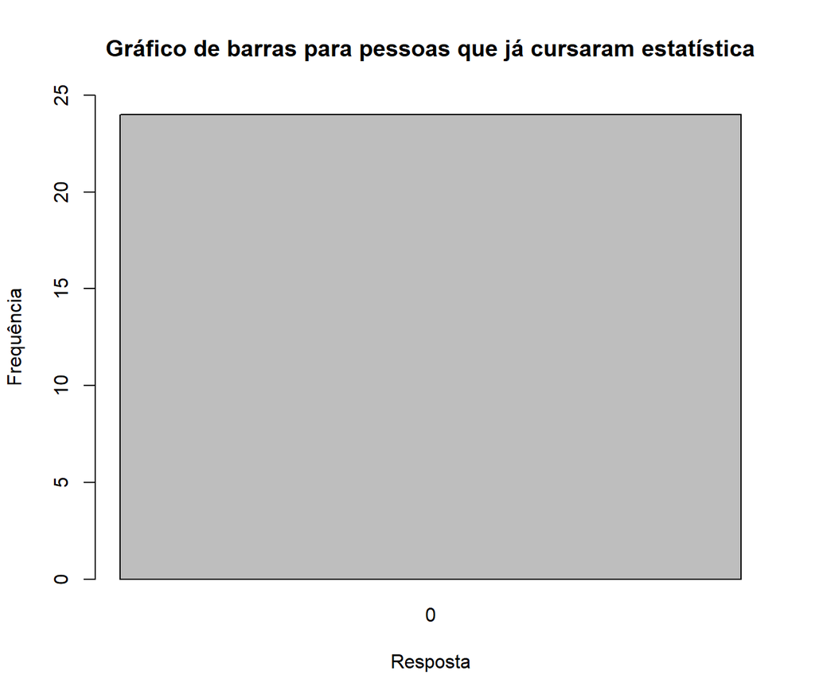

```r
barplot(da.cursou$Freq, names.arg = da.cursou$niveis, main = "Gráfico de barras para pessoas que já cursaram estatística", xlab = "Resposta", ylab = "Frequência", ylim = c(0,25))
```

### Qual is softwares estatísticos você usa ou já usou?

#### Tabela 1

#### Gráfico 1

Variável sem tratamento

### Qual seu sexo?

#### Tabela

```r
fa_sex <- table(tabela$sexo)
fr_sex <- prop.table(fa_sex)
fac_sex <- cumsum(fr_sex)
da.sex <- data.frame(niveis = names(fa_sex), Freq=as.vector(fa_sex), FreqR=as.vector(fr_sex),FreqA=as.vector(fac_sex))
pander:::pander(da.sex) # gerando a tabela
```

| niveis | Freq | FreqR | FreqA |
| --- | --- | --- | --- |
| Feminino | 4 | 0.1667 | 0.1667 |
| Masculino | 20 | 0.8333 | 1 |

#### Gráfico

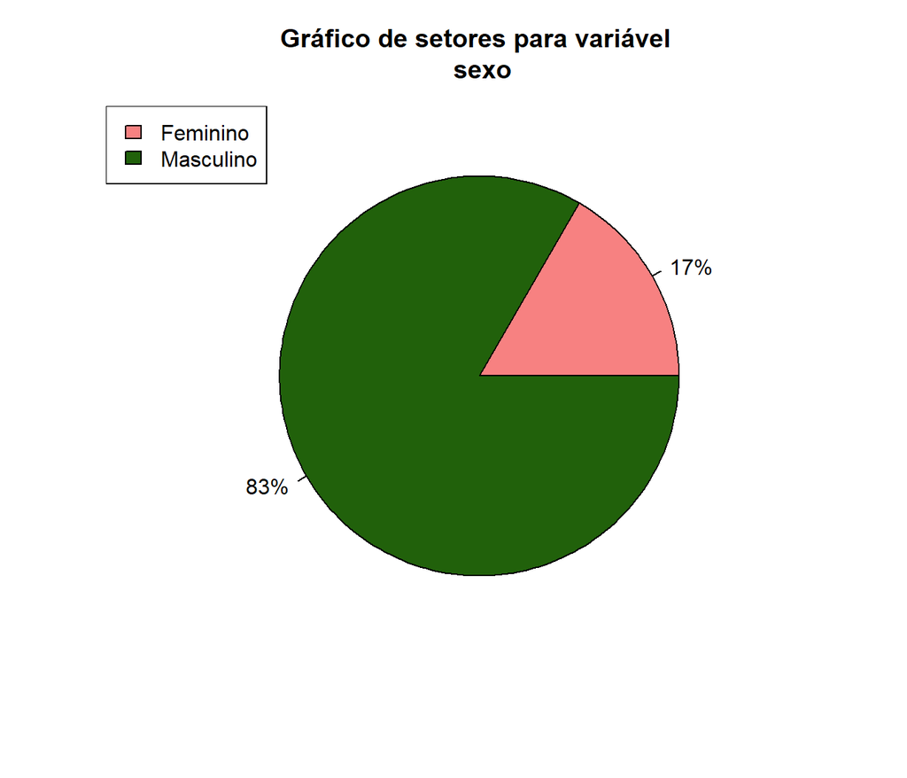

```r
pie(da.sex$Freq, labels = percent(da.sex$FreqR), col = paleta,main = "Gráfico de setores para variável \n sexo")
legend("topleft",legend = da.sex$niveis, fill = paleta)
```

### Quantos irmãos você tem?

#### Tabela

```r
fa_irmao <- table(tabela$irmao)
fr_irmao <- prop.table(fa_irmao)
fac_irmao <-  cumsum(fr_irmao)
da.irmao <- data.frame(niveis = names(fa_irmao), Freq=as.vector(fa_irmao), FreqR=as.vector(fr_irmao),FreqA=as.vector(fac_irmao))
da.irmao$niveis <- as.vector(da.irmao$niveis)
da.irmao[4,] <- NA
da.irmao[4,] <- 0
#plyr::arrange(da.irmao,da.irmao$niveis)
pander:::pander(da.irmao) # gerando a tabela
```

| niveis | Freq | FreqR | FreqA |
| --- | --- | --- | --- |
| 1 | 14 | 0.5833 | 0.5833 |
| 2 | 6 | 0.25 | 0.8333 |
| 3 | 4 | 0.1667 | 1 |
| 0 | 0 | 0 | 0 |

#### Gráfico

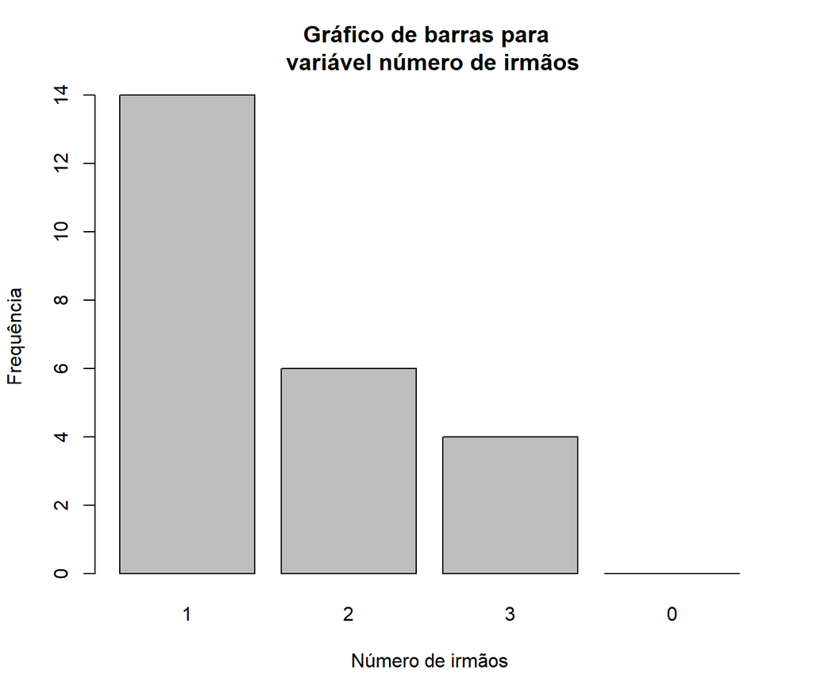

```r
barplot(da.irmao$Freq, names.arg = da.irmao$niveis, main = "Gráfico de barras para \n variável número de irmãos", xlab = "Número de irmãos", ylab = "Frequência")
```

### Qual seu meio de transporte predominante para ir à Universidade?

#### Tabela

```r
fa_transporte <- table(tabela$transporte)
fr_transporte <- prop.table(fa_transporte)
fac_transporte <- cumsum(fr_transporte)
da.transporte <- data.frame(niveis = names(fa_transporte), Freq = as.vector(fa_transporte),FreqR = as.vector(fr_transporte), FreqA = as.vector(fac_transporte))
da.transporte$niveis <- tolower(iconv(da.transporte$niveis,to ='ASCII//TRANSLIT',from = "UTF-8"))
da.transporte <- plyr::arrange(da.transporte,da.transporte$Freq)



pander:::pander(da.transporte)
```

| niveis | Freq | FreqR | FreqA |
| --- | --- | --- | --- |
| servico fretado de van/onibus | 1 | 0.04167 | 0.5 |
| a pe | 2 | 0.08333 | 0.08333 |
| carro/moto proprio | 9 | 0.375 | 0.4583 |
| transporte publico | 12 | 0.5 | 1 |

#### Gráfico

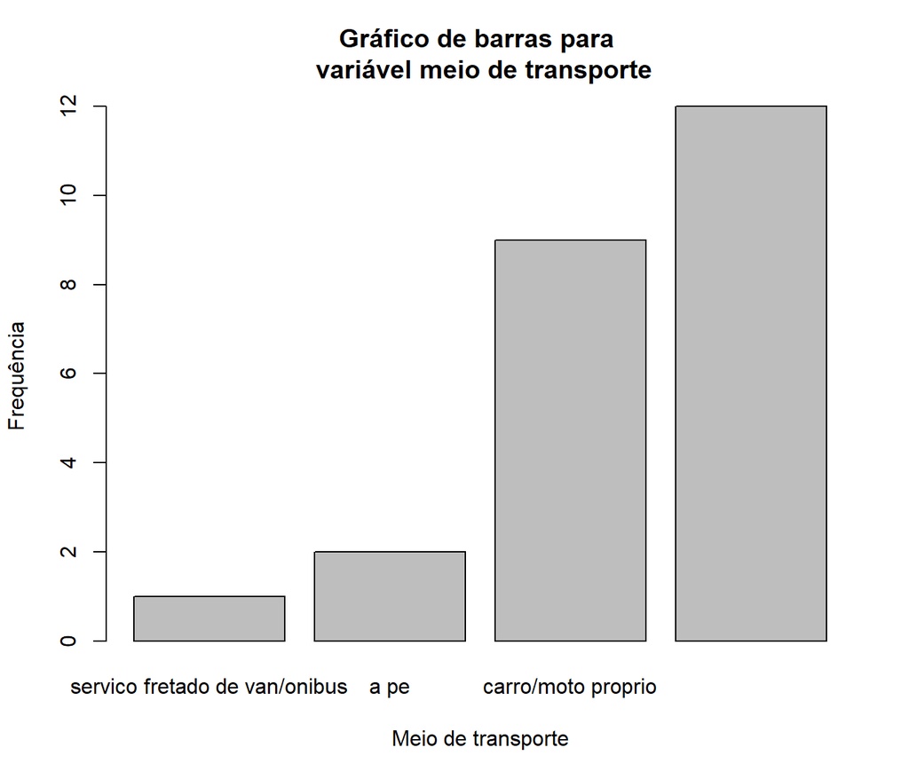

```r
barplot(da.transporte$Freq, names.arg = da.transporte$niveis, main = "Gráfico de barras para \n variável meio de transporte", ylab = "Frequência", xlab = "Meio de transporte")
```

#### Gráfico 1

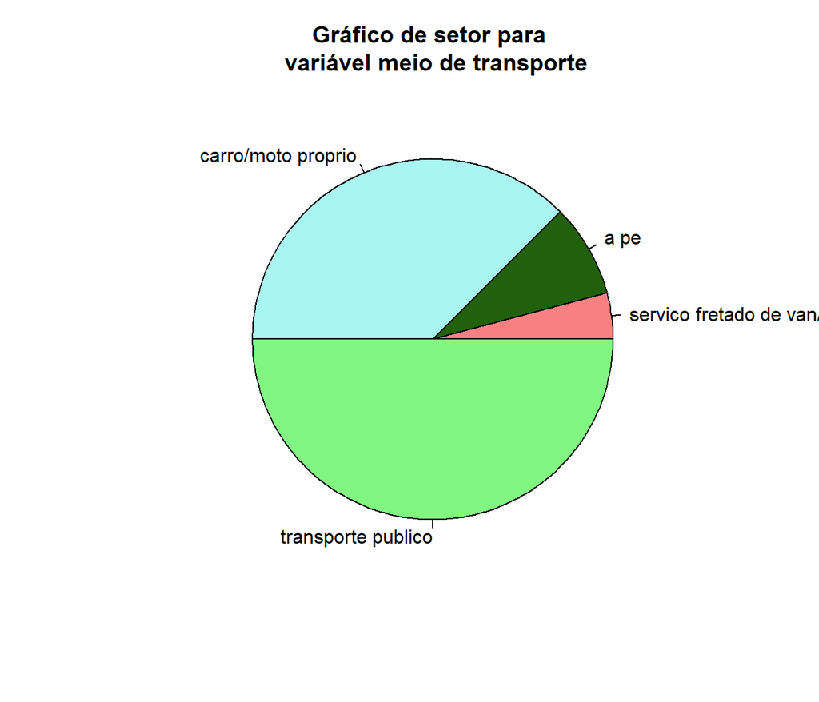

```r
pie(da.transporte$Freq, labels = da.transporte$niveis,col = paleta, main = "Gráfico de setor para \n variável meio de transporte")
```

### Possui habilitação para dirigir qual categoria?

#### Tabela 1

Todas as respostas

```r
fa_habilitacao <- table(tabela$habilitacao)
fr_habilitacao <- prop.table(fa_habilitacao)
fac_habilitacao <- cumsum(fr_habilitacao)
da.habilitacao <- data.frame(niveis = names(fa_habilitacao),
                             Freq=as.vector(fa_habilitacao),
                             FreqR = as.vector(fr_habilitacao),
                             FreqA = as.vector(fac_habilitacao))
da.habilitacao$niveis <- as.vector(da.habilitacao$niveis)
da.habilitacao[4,1] <- "A (Moto)"
da.habilitacao[5,1] <- "Superior à B"
da.habilitacao$niveis <- tolower(iconv(da.habilitacao$niveis,to ='ASCII//TRANSLIT',from = "UTF-8"))
da.habilitacao[4,c(2,3,4)] <- c(0,0,0)
da.habilitacao[5,c(2,3,4)] <- c(0,0,0)
da.habilitacao <- plyr::arrange(da.habilitacao,da.habilitacao$Freq)

pander:::pander(da.habilitacao) # gerando a tabela
```

| niveis | Freq | FreqR | FreqA |
| --- | --- | --- | --- |
| a (moto) | 0 | 0 | 0 |
| NA | 0 | 0 | 0 |
| a e b (moto e carro) | 5 | 0.2083 | 0.2083 |
| nao | 5 | 0.2083 | 1 |
| b (carro) | 14 | 0.5833 | 0.7917 |

#### Gráfico

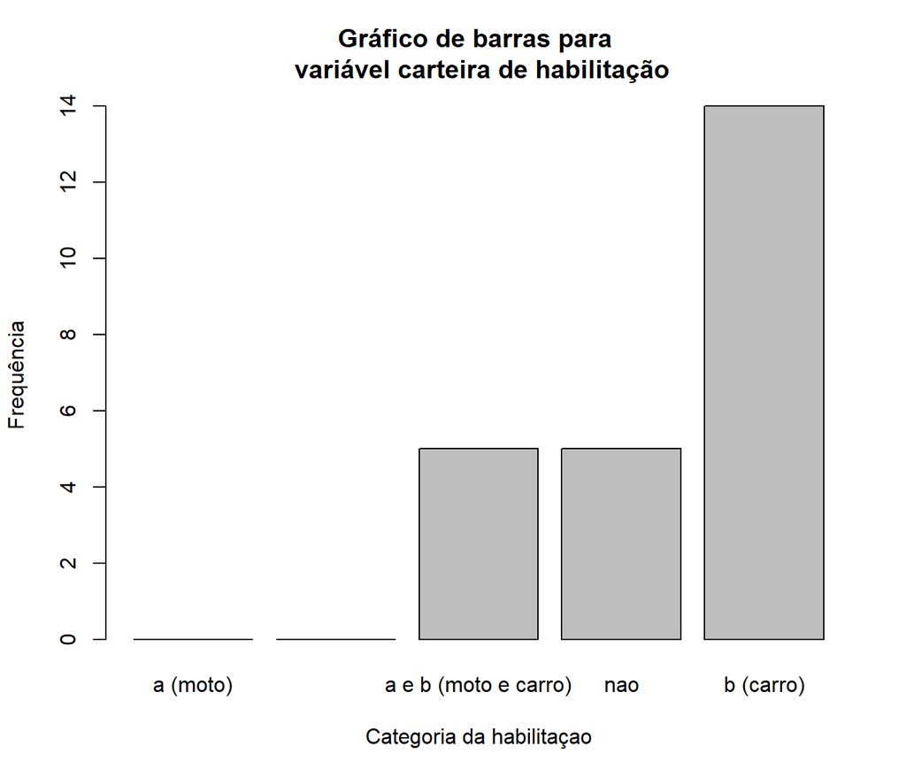

```r
barplot(da.habilitacao$Freq, names.arg = da.habilitacao$niveis, main = "Gráfico de barras para \n variável carteira de habilitação", ylab = "Frequência", xlab = "Categoria da habilitaçao")
```

### Em média quanto tempo você demora para chegar a Universidade?

#### Tabela 1

```r
fa_temp_ate_univ <- table(tabela$temp_ate_univ)
fr_temp_ate_univ <- prop.table(fa_temp_ate_univ)
fac_temp_ate_univ <-  cumsum(fr_temp_ate_univ)
da.temp_ate_univ <- data.frame(niveis = names(fa_temp_ate_univ),
                               Freq = as.vector(fa_temp_ate_univ),
                               FreqR = as.vector(fr_temp_ate_univ),
                               FreqA = as.vector(fac_temp_ate_univ))
da.temp_ate_univ$niveis <- tolower(iconv(da.temp_ate_univ$niveis,to ='ASCII//TRANSLIT',from = "UTF-8"))

pander:::pander(da.temp_ate_univ)
```

| niveis | Freq | FreqR | FreqA |
| --- | --- | --- | --- |
| 2 | 1 | 0.04167 | 0.04167 |
| 10 | 2 | 0.08333 | 0.125 |
| 15 | 5 | 0.2083 | 0.3333 |
| 18 | 1 | 0.04167 | 0.375 |
| 20 | 3 | 0.125 | 0.5 |
| 27 | 1 | 0.04167 | 0.5417 |
| 30 | 2 | 0.08333 | 0.625 |
| 40 | 2 | 0.08333 | 0.7083 |
| 45 | 1 | 0.04167 | 0.75 |
| 60 | 2 | 0.08333 | 0.8333 |
| 65 | 1 | 0.04167 | 0.875 |
| 75 | 1 | 0.04167 | 0.9167 |
| 90 | 1 | 0.04167 | 0.9583 |
| 100 | 1 | 0.04167 | 1 |

#### Gráfico 1

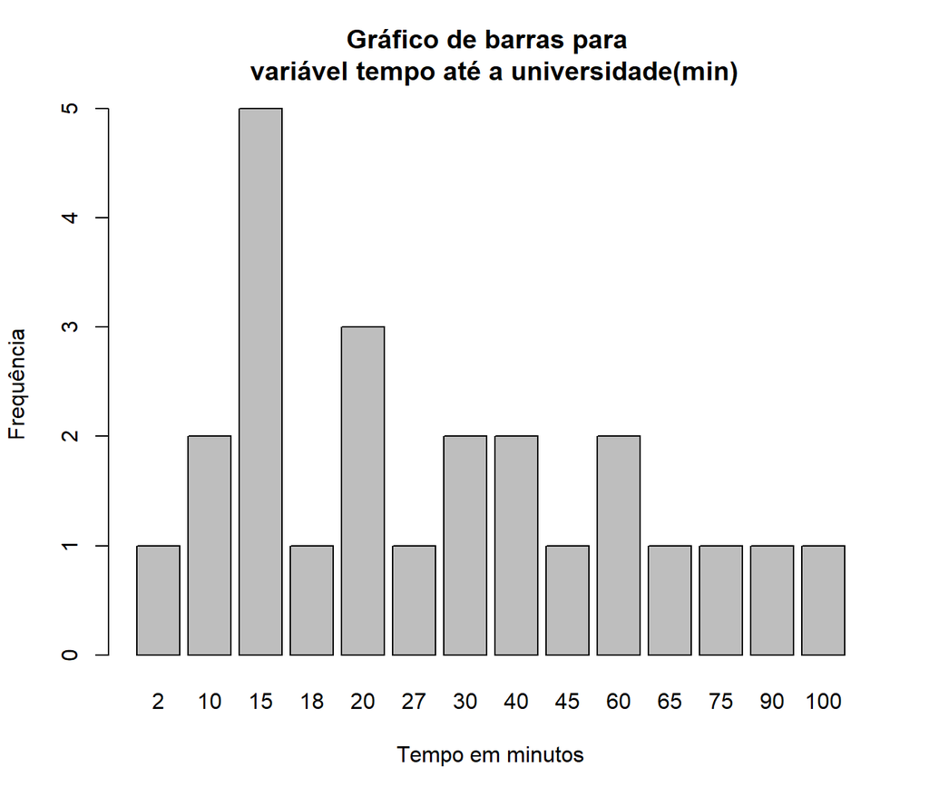

```r
barplot(da.temp_ate_univ$Freq, names.arg = da.temp_ate_univ$niveis,main = "Gráfico de barras para \n variável tempo até a universidade(min)", ylab = "Frequência", xlab = "Tempo em minutos")
```

#### Gráfico 2

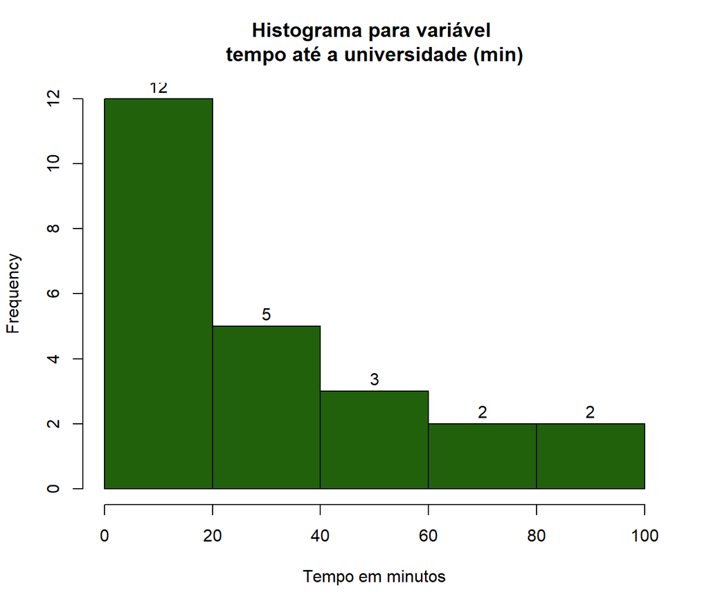

```r
hist(tabela$temp_ate_univ, labels = TRUE, main = "Histograma para variável \n tempo até a universidade (min) ", xlab = 'Tempo em minutos',col = paleta[2])
```

### Qual a sua altura?

#### Tabela

```r
fa_altura <- table(tabela$altura)
fr_altura <- prop.table(fa_altura)
fac_altura <- cumsum(fr_altura)
da.altura <- data.frame(niveis= names(fa_altura),
                        Freq = as.vector(fa_altura),
                        FreqR = as.vector(fr_altura),
                        FreqA = as.vector(fac_altura))
da.altura$niveis <- tolower(iconv(da.altura$niveis,to ='ASCII//TRANSLIT',from = "UTF-8"))
pander:::pander(da.altura) # gerando a tabela
```

| niveis | Freq | FreqR | FreqA |
| --- | --- | --- | --- |
| 154 | 1 | 0.04167 | 0.04167 |
| 155 | 1 | 0.04167 | 0.08333 |
| 156 | 1 | 0.04167 | 0.125 |
| 167 | 1 | 0.04167 | 0.1667 |
| 168 | 1 | 0.04167 | 0.2083 |
| 169 | 1 | 0.04167 | 0.25 |
| 171 | 2 | 0.08333 | 0.3333 |
| 172 | 1 | 0.04167 | 0.375 |
| 173 | 1 | 0.04167 | 0.4167 |
| 174 | 2 | 0.08333 | 0.5 |
| 175 | 4 | 0.1667 | 0.6667 |
| 176 | 1 | 0.04167 | 0.7083 |
| 177 | 1 | 0.04167 | 0.75 |
| 180 | 2 | 0.08333 | 0.8333 |
| 182 | 1 | 0.04167 | 0.875 |
| 184 | 1 | 0.04167 | 0.9167 |
| 187 | 1 | 0.04167 | 0.9583 |
| 190 | 1 | 0.04167 | 1 |

#### Gráfico

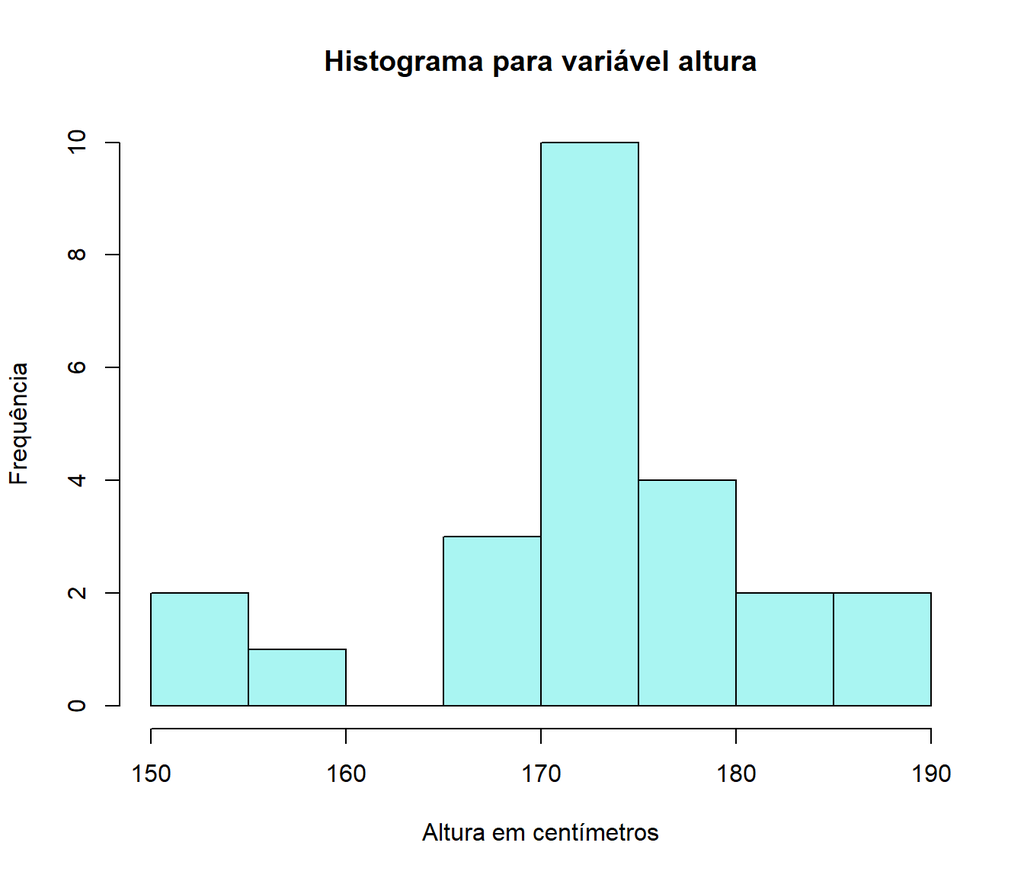

```r
hist(tabela$altura, main = "Histograma para variável altura", xlab = "Altura em centímetros", ylab = "Frequência",col = paleta[3])
```

### Qual o seu peso?

#### Tabela

```r
fa_peso <- table(tabela$peso)
fr_peso <-  prop.table(fa_peso)
fac_peso <-  cumsum(fr_peso)
da.peso <- data.frame(niveis = names(fa_peso),
                      Freq = as.vector(fa_peso),
                      FreqR = as.vector(fr_peso),
                      FreqA = as.vector(fac_peso))

pander:::pander(da.peso) # gerando a tabela
```

| niveis | Freq | FreqR | FreqA |
| --- | --- | --- | --- |
| 45 | 1 | 0.04167 | 0.04167 |
| 50 | 1 | 0.04167 | 0.08333 |
| 51 | 1 | 0.04167 | 0.125 |
| 58 | 1 | 0.04167 | 0.1667 |
| 60 | 1 | 0.04167 | 0.2083 |
| 62 | 1 | 0.04167 | 0.25 |
| 63 | 1 | 0.04167 | 0.2917 |
| 65 | 3 | 0.125 | 0.4167 |
| 66 | 1 | 0.04167 | 0.4583 |
| 67 | 1 | 0.04167 | 0.5 |
| 68 | 1 | 0.04167 | 0.5417 |
| 70 | 4 | 0.1667 | 0.7083 |
| 73 | 2 | 0.08333 | 0.7917 |
| 76 | 1 | 0.04167 | 0.8333 |
| 79 | 2 | 0.08333 | 0.9167 |
| 80 | 2 | 0.08333 | 1 |

#### Gráfico

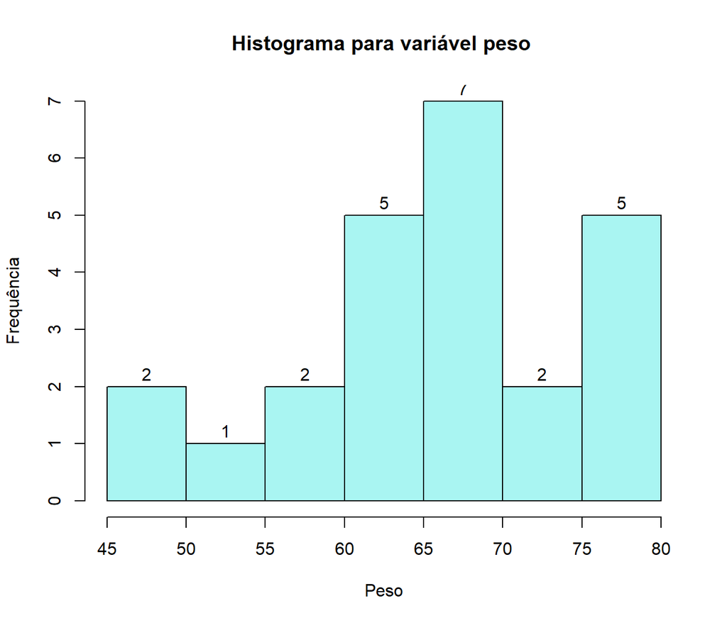

```r
hist(tabela$peso, labels = TRUE, main = "Histograma para variável peso ", xlab = "Peso", ylab = "Frequência",col = paleta[3])
```

### Toca algum instrumento musical?

#### Tabela

```r
for(i in length(tabela$instrumento)){
  if(tabela$instrumento[i] == "Sim,guitarra"){
    tabela$instrumento[i] <- "Guitarra"
  }
}
fa_instrumento <- table(tabela$instrumento)
fr_instrumento <- prop.table(fa_instrumento)
fac_instrumento <- cumsum(fr_instrumento)
da.instrumento <- data.frame(niveis = names(fa_instrumento),
                             Freq = as.vector(fa_instrumento),
                             FreqR = as.vector(fr_instrumento),
                             FreqA= as.vector(fac_instrumento))
da.instrumento$niveis <- tolower(iconv(da.instrumento$niveis,to ='ASCII//TRANSLIT',from = "UTF-8"))

pander:::pander(da.instrumento) # gerando a tabela
```

| niveis | Freq | FreqR | FreqA |
| --- | --- | --- | --- |
| clarinete | 1 | 0.04167 | 0.04167 |
| guitarra | 2 | 0.08333 | 0.125 |
| nao | 13 | 0.5417 | 0.6667 |
| piano | 1 | 0.04167 | 0.7083 |
| sim,guitarra | 1 | 0.04167 | 0.75 |
| trompete; | 1 | 0.04167 | 0.7917 |
| violao | 2 | 0.08333 | 0.875 |
| violao | 2 | 0.08333 | 0.9583 |
| violino | 1 | 0.04167 | 1 |

#### Gráfico

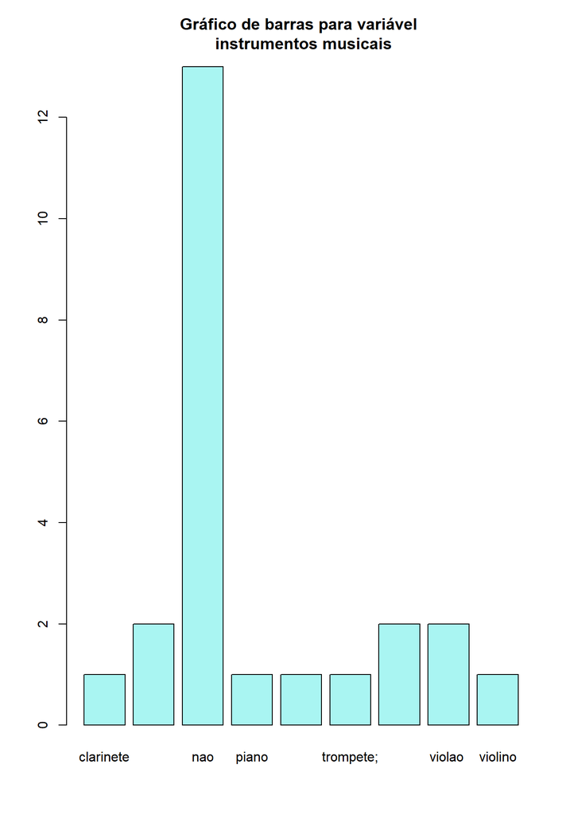

```r
barplot(da.instrumento$Freq, names.arg = da.instrumento$niveis, main = "Gráfico de barras para variável \n instrumentos musicais",col = paleta[3])
```

### De quais redes sociais você participa?

#### Tabela

```r
fa_facebook <- table(tabela$facebook)
fr_facebook <- prop.table(fa_facebook)
fac_facebook <- cumsum(fr_facebook)
da.facebook <- data.frame(niveis = names(fa_facebook),
                          Freq = as.vector(fa_facebook),
                          FreqR = as.vector(fr_facebook),
                          FreqA = as.vector(fac_facebook))
da.facebook$niveis <- tolower(iconv(da.facebook$niveis,to ='ASCII//TRANSLIT',from = "UTF-8"))

pander:::pander(da.facebook) # gerando a tabela
```

| niveis | Freq | FreqR | FreqA |
| --- | --- | --- | --- |
| facebook | 1 | 0.04167 | 0.04167 |
| facebook, google+, instagram | 1 | 0.04167 | 0.08333 |
| facebook, google+, instagram, outras | 1 | 0.04167 | 0.125 |
| facebook, instagram | 6 | 0.25 | 0.375 |
| facebook, instagram, linkedin | 2 | 0.08333 | 0.4583 |
| facebook, instagram, outras | 2 | 0.08333 | 0.5417 |
| facebook, linkedin | 1 | 0.04167 | 0.5833 |
| facebook, twitter | 1 | 0.04167 | 0.625 |
| facebook, twitter, instagram | 2 | 0.08333 | 0.7083 |
| facebook, twitter, instagram, linkedin | 2 | 0.08333 | 0.7917 |
| facebook, twitter, instagram, linkedin, outras | 1 | 0.04167 | 0.8333 |
| google+, linkedin | 1 | 0.04167 | 0.875 |
| instagram, linkedin | 1 | 0.04167 | 0.9167 |
| outras | 2 | 0.08333 | 1 |

### Em média quantas vezes você usa táxi aplicativo de transporte durante o mês?

#### Tabela 1

```r
fa_taxi_pmes <- table(tabela$taxi_pmes)
fr_taxi_pmes <- prop.table(fa_taxi_pmes)
fac_taxi_pmes <- cumsum(fr_taxi_pmes)
da.taxi_pmes <- data.frame(niveis = names(fa_taxi_pmes),
                           Freq = as.vector(fa_taxi_pmes),
                           FreqR = as.vector(fr_taxi_pmes),
                           FreqA = as.vector(fac_taxi_pmes))

pander:::pander(da.taxi_pmes) # gerando a tabela
```

| niveis | Freq | FreqR | FreqA |
| --- | --- | --- | --- |
| 0 | 6 | 0.25 | 0.25 |
| 1 | 3 | 0.125 | 0.375 |
| 2 | 5 | 0.2083 | 0.5833 |
| 3 | 2 | 0.08333 | 0.6667 |
| 4 | 1 | 0.04167 | 0.7083 |
| 5 | 3 | 0.125 | 0.8333 |
| 6 | 1 | 0.04167 | 0.875 |
| 7 | 1 | 0.04167 | 0.9167 |
| 8 | 2 | 0.08333 | 1 |

#### Gráfico 1

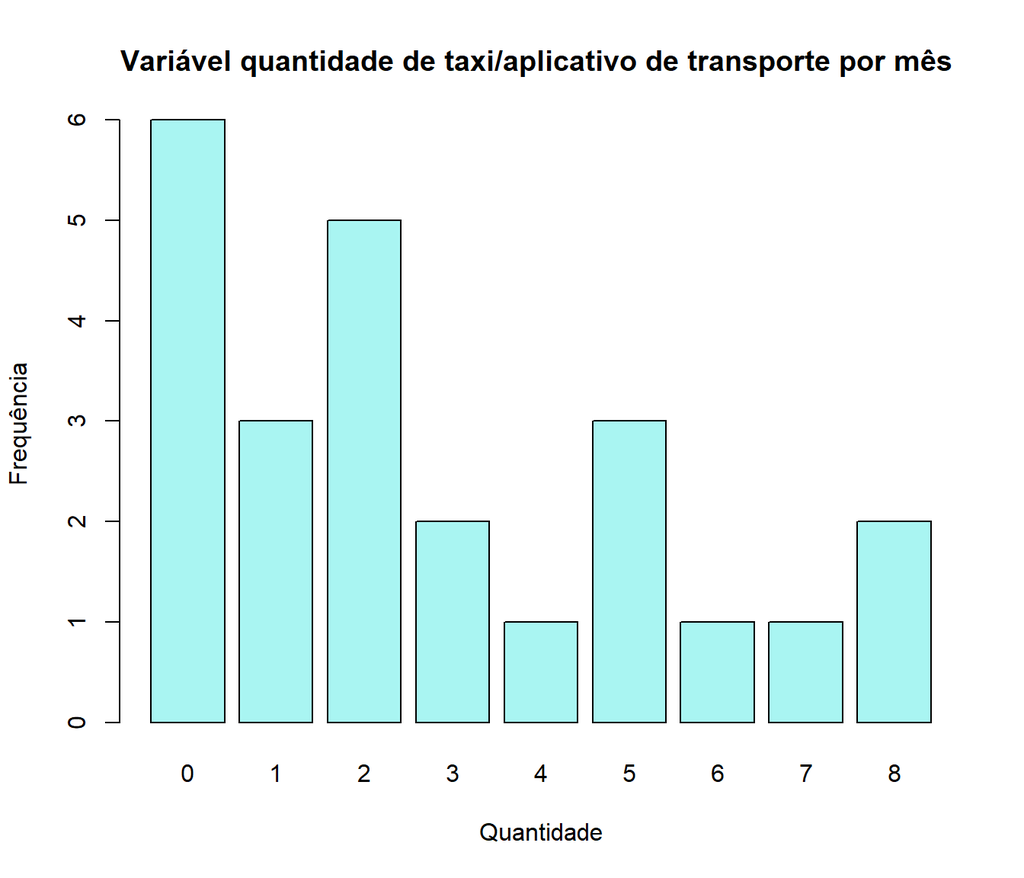

```r
barplot(da.taxi_pmes$Freq, names.arg = da.taxi_pmes$niveis, main = "Variável quantidade de taxi/aplicativo de transporte por mês ", ylab = "Frequência", xlab = "Quantidade",col = paleta[3])
```

### Você é o provedor da conta de NETFLIX da sua família amigos?

#### Tabela

```r
fa_netflix <- table(tabela$netflix)
fr_netflix <- prop.table(fa_netflix)
fac_netflix <- cumsum(fr_netflix)
da.netflix <- data.frame(niveis = names(fa_netflix),
                         Freq = as.vector(fa_netflix),
                         FreqR = as.vector(fr_netflix),
                         FreqA = as.vector(fac_netflix))
da.netflix$niveis <-   tolower(iconv(da.netflix$niveis,to ='ASCII//TRANSLIT',from = "UTF-8"))
da.netflix <- arrange(da.netflix,da.netflix$Freq)

pander:::pander(da.netflix) # gerando a tabela
```

| niveis | Freq | FreqR | FreqA |
| --- | --- | --- | --- |
| nao tenho conta no netflix | 3 | 0.125 | 0.6667 |
| sim | 8 | 0.3333 | 1 |
| nao | 13 | 0.5417 | 0.5417 |

#### Gráfico

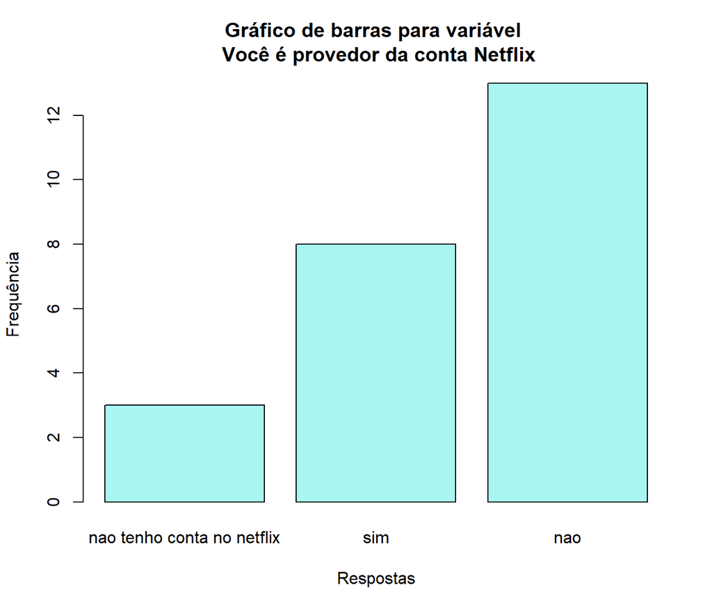

```r
barplot(da.netflix$Freq, names.arg = da.netflix$niveis, main = "Gráfico de barras para variável \n Você é provedor da conta Netflix", ylab = "Frequência", xlab = "Respostas",col = paleta[3])
```

#### Tabela

```r
fa_anos_foto <- table(tabela$anos_foto)
fr_anos_foto <- prop.table(fa_anos_foto)
fac_anos_foto <- cumsum(fr_anos_foto)
da.anos_foto <- data.frame(niveis = names(fa_anos_foto),
                           Freq = as.vector(fa_anos_foto),
                           FreqR = as.vector(fr_anos_foto),
                           FreqA = as.vector(fac_anos_foto))

pander:::pander(da.anos_foto) # gerando a tabela
```

| niveis | Freq | FreqR | FreqA |
| --- | --- | --- | --- |
| 30 | 1 | 0.04167 | 0.04167 |
| 32 | 1 | 0.04167 | 0.08333 |
| 35 | 1 | 0.04167 | 0.125 |
| 37 | 1 | 0.04167 | 0.1667 |
| 38 | 1 | 0.04167 | 0.2083 |
| 40 | 2 | 0.08333 | 0.2917 |
| 41 | 1 | 0.04167 | 0.3333 |
| 43 | 2 | 0.08333 | 0.4167 |
| 44 | 1 | 0.04167 | 0.4583 |
| 45 | 3 | 0.125 | 0.5833 |
| 47 | 1 | 0.04167 | 0.625 |
| 48 | 1 | 0.04167 | 0.6667 |
| 50 | 2 | 0.08333 | 0.75 |
| 52 | 2 | 0.08333 | 0.8333 |
| 55 | 1 | 0.04167 | 0.875 |
| 56 | 1 | 0.04167 | 0.9167 |
| 57 | 2 | 0.08333 | 1 |

#### Gráfico

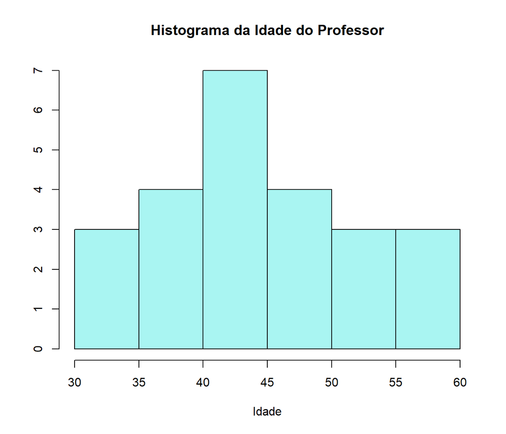

```r
tabela$anos_foto <- as.numeric(tabela$anos_foto)
h <- hist(tabela$anos_foto,main = "Histograma da Idade do Professor", xlab = "Idade", ylab = "", col = paleta[3])
```

### Qual a sua principal expectativa após a conclusão do curso?

#### Tabela

```r
fa_expect_curso <- table(tabela$expect_curso)
fr_expect_curso <- prop.table(fa_expect_curso)
fac_expect_curso <- cumsum(fr_expect_curso)
da.expect_curso <- data.frame(niveis = names(fa_expect_curso),
                              Freq = as.vector(fa_expect_curso),
                              FreqR = as.vector(fr_expect_curso),
                              FreqA = as.vector(fac_expect_curso))
da.expect_curso$niveis <- tolower(iconv(da.expect_curso$niveis,to ='ASCII//TRANSLIT',from = "UTF-8"))

da.expect_curso <- arrange(da.expect_curso, da.expect_curso$Freq)

pander:::pander(da.expect_curso) # gerando a tabela
```

| niveis | Freq | FreqR | FreqA |
| --- | --- | --- | --- |
| fazer outra graduacao | 2 | 0.08333 | 1 |
| continuar estudos de pos graduacao | 7 | 0.2917 | 0.9167 |
| conseguir um emprego. | 15 | 0.625 | 0.625 |

#### Gráfico

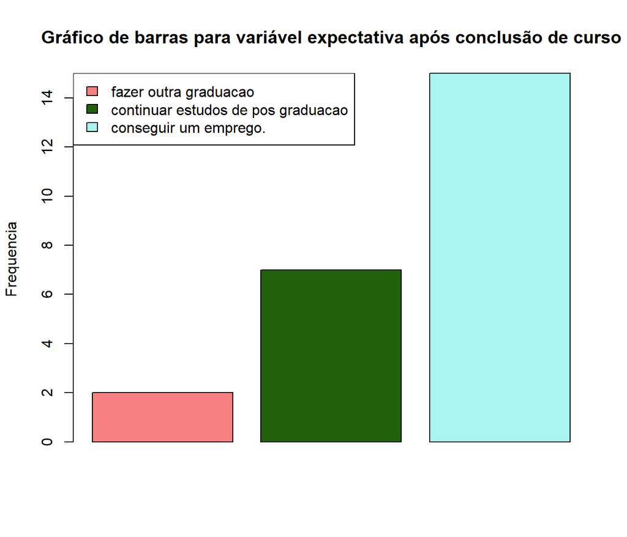

```r
barplot(da.expect_curso$Freq, names.arg = "", main = 'Gráfico de barras para variável expectativa após conclusão de curso', ylab = 'Frequencia', xlab = '',col = paleta)
legend("topleft",da.expect_curso$niveis,fill = paleta)
```

### Que nota voce daria para seu curso até o momento em uma escala de 0 a 100?

#### Tabela

```r
fa_notacurso <- table(tabela$notacurso)
fr_notacurso <- prop.table(fa_notacurso)
fac_notacurso <- cumsum(fr_notacurso)
da.notacurso <- data.frame(niveis = names(fa_notacurso),
                           Freq = as.vector(fa_notacurso),
                           FreqR = as.vector(fr_notacurso),
                           FreqA = as.vector(fac_notacurso))
pander:::pander(da.notacurso) # gerando a tabela
```

| niveis | Freq | FreqR | FreqA |
| --- | --- | --- | --- |
| 60 | 3 | 0.125 | 0.125 |
| 65 | 1 | 0.04167 | 0.1667 |
| 70 | 3 | 0.125 | 0.2917 |
| 75 | 1 | 0.04167 | 0.3333 |
| 77 | 1 | 0.04167 | 0.375 |
| 78 | 2 | 0.08333 | 0.4583 |
| 79 | 1 | 0.04167 | 0.5 |
| 80 | 5 | 0.2083 | 0.7083 |
| 85 | 3 | 0.125 | 0.8333 |
| 90 | 2 | 0.08333 | 0.9167 |
| 94 | 1 | 0.04167 | 0.9583 |
| 98 | 1 | 0.04167 | 1 |

#### Gráfico

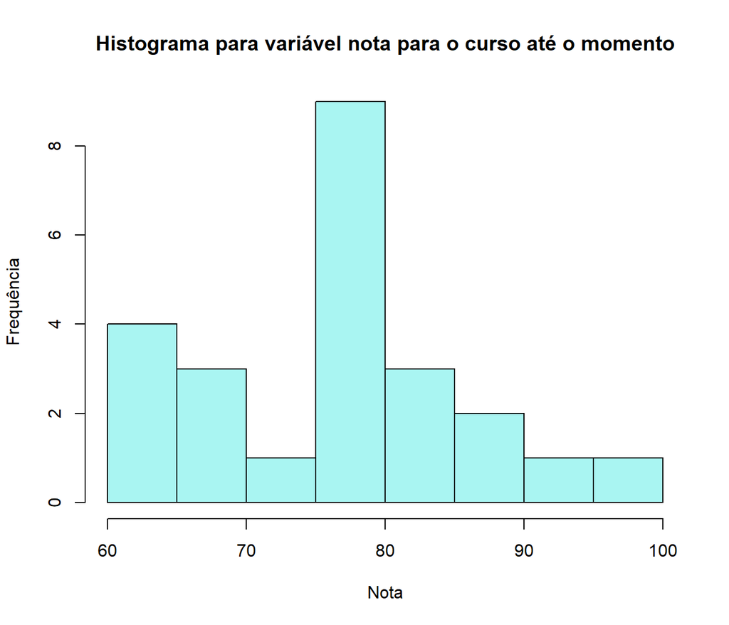

```r
hist(tabela$notacurso, labels = FALSE, main = "Histograma para variável nota para o curso até o momento", xlab = "Nota", ylab = "Frequência",col = paleta[3])
```